🦠 **Reviews in the Post-Pandemic Era** 🦠

Sorted *Worst-Best:* Filtered for Time and Collaboration

**Likeliness to Recommend**

**Why did you choose this rating?**

**What could have improved your experience?**

**Professional training session**

**Facilitator**

**Date**

Likert Plot (Blue = Agree, White = Disagree)

3

its was just hard to do alone...

more collaborations with our own school...

EL Virtual Bootcamp

Mandy

May, 19 2020

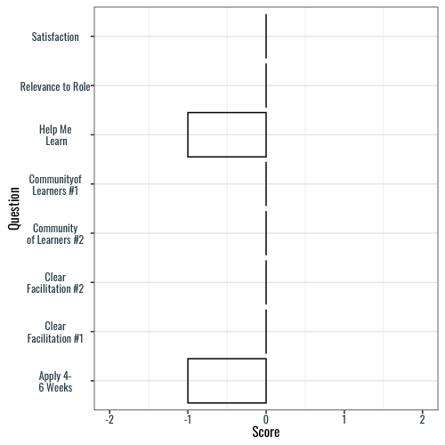

4

so much info and new way of teaching/learning that it was overwhelming

slowing down and more time to work within my grade level and talk with those teachers

EL Virtual Bootcamp

Mandy

May, 19 2020

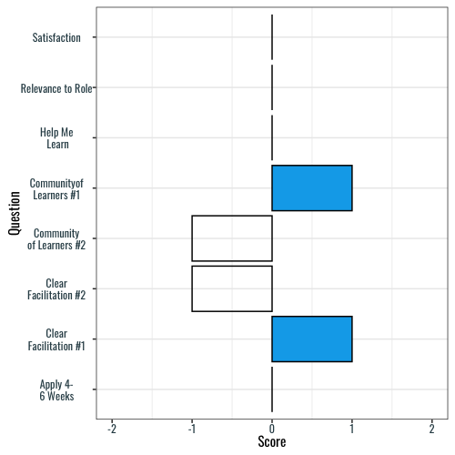

6

I participated in EL's profession development online courses concerning curriculum and teaching the material, so much of this seemed repetitive. However, because the material is brand new, it was still worth it for me as a review.

More chance to collaborate with same grade-level teachers. More opportunity to investigate the material with classroom teachers and formulate questions that would need answering.

EL Virtual Bootcamp

Vaishali

May, 19 2020

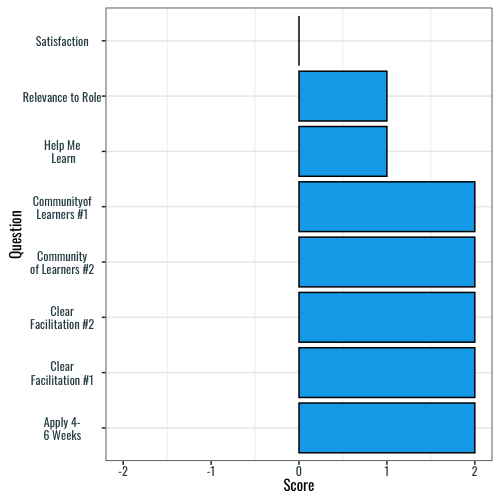

6

It went well given the situation. I'm not sure I would recommend this format as the only method of bootcamp.

A bit more time experiencing some of the activities that students will participate in.

EL Virtual Bootcamp

Vaishali

May, 19 2020

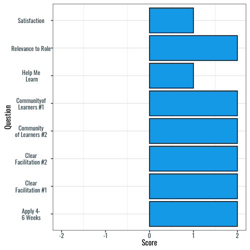

6

Blank

more time with resources

Guidebooks Diverse Learners Vocabulary, Day 1

Holli

Nov, 19 2020

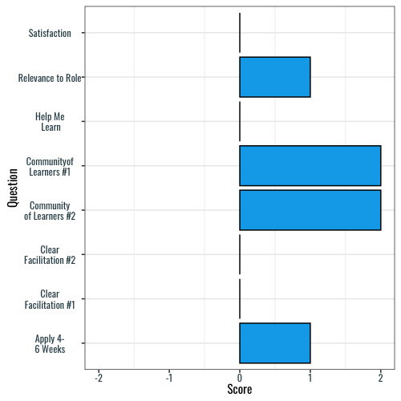

8

It was useful and educational, but I missed out on time to work with other teachers.

Having more time to collaborate with fellow teachers.

EL Virtual Bootcamp

Vaishali

May, 19 2020

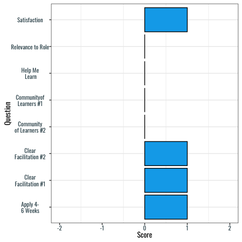

8

I felt like I was well supported throughout the bootcamp.

More time to talk to grade level teachers

EL Virtual Bootcamp

Vaishali

May, 19 2020

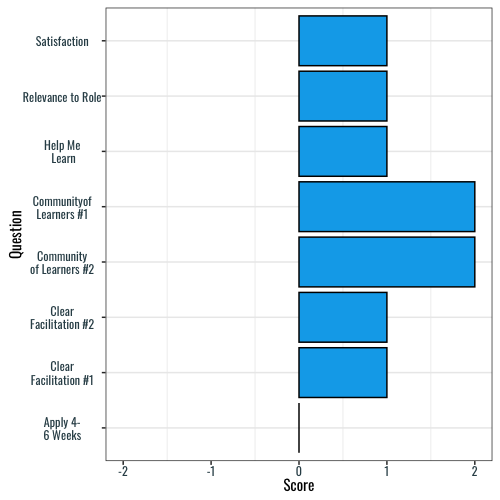

8

I thought it was pretty good but at times I didn't feel we got the answers or things we needed (videos, etc.)

Probably more time to dive in and an in person training but unfortunately we didn't have either of those opportunities

EL Virtual Bootcamp

Vaishali

May, 19 2020

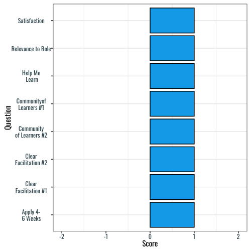

8

It was a good lesson, but didn't have any engagement besides talking. Explanations and strategies given were helpful.

More talking and time to collaborate and plan

Guidebooks Diverse Learners Vocabulary, Day 1

Holli

Nov, 19 2020

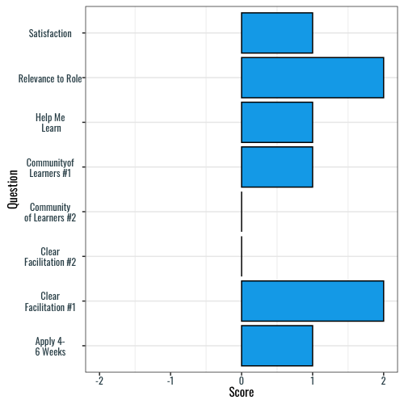

8

I think the information presented was strong. I did not score a 10 because I would have liked to see more opportunities for engagement and maybe some practice. Additionally, the session was heavy in theory and as practitioners, sometimes, we need actionable solutions without the "guesswork"

More time to engage in discussion- not so heavy on the facilitator speaking and engaging everyone. Reflections & small group tasks would be helpful.

Guidebooks Diverse Learners Vocabulary, Day 1

Holli

Nov, 19 2020

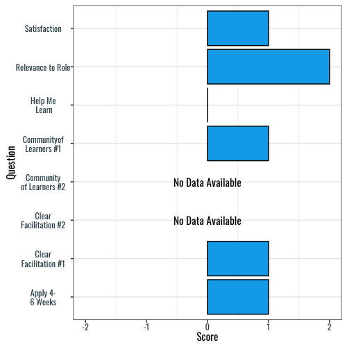